# O15-task macBP gamma & sniff-locked spectrograms

Zelano Lab — O15 analysis

2026-06-24

## 1. Methods

**Data.** O15 intracranial/scalp recordings, preprocessed to 500 Hz (high-pass 0.03 Hz, low-pass ~Nyquist, notch 60/120/180 Hz). Analysis channels are the bipolar macro pairs `macBP1..5` (count varies; sessions without any `macBP` are excluded — O15 EEG/macros are sometimes absent). Only finals from the current preprocessing run (modified on/after 2026-06-24) are analysed. Sessions are grouped **DupiS1 / DupiS2 / DupiS3** (Dupi study, recording 1/2/3) and **Control** (all non-Dupi).

**FOOOF.** Per session, each `macBP` PSD (FieldTrip `ft_freqanalysis`, `mtmfft`, 2 s / 50%-overlap segments, piped via EEGLAB `eeglab2fieldtrip`) was parameterized with FOOOF (brainstorm `process_fooof`, aperiodic_mode = fixed). The **gamma** band is 30–58 Hz. `bestMac` = the channel with the largest **periodic** gamma peak; if no `macBP` has a fitted gamma peak, we fall back to the largest **flattened** (PSD ÷ aperiodic) power in band (`selectionMethod`). *(Identical machinery to the cue analysis — `cue_fooof_macBP` is reused unchanged.)*

**Spectrograms (single shared baseline).** For each session’s `bestMac`, per-trial time-frequency power was obtained from EEGLAB `newtimef` (Morlet [3 0.8], 100 log-spaced freqs 2–120 Hz; single- trial `alltfX` → |·|²), separately for the three sniff lockings. Power was normalized to **one shared baseline** taken from a window **before the first trial-start sniff** (`firstStart − guard − ≤30 s … firstStart − 1 s`; wavelet edge frames trimmed). The baseline-z is computed via the lab’s bootstrap routine `myChanZscore`: per frequency, the trial-mean power is expressed as **z = (power − baselineMean) / baselineSD** (baseline-SD units). Using *one* baseline for all three sniff types puts them on a single comparable scale despite very different trial counts (a SEM-style z would make the high-count *free* maps spuriously hotter). Heat = *z vs the single pre-task baseline*; the **mean respiration trace** is overlaid (black, right axis). Display −1000…+3000 ms.

*Noise rejection (sharp-deflection rule).* A sniff is flagged **noisy** if its raw `bestMac` epoch (−1.75…+5.75 s) contains any 10 ms window with a max-to-min range **> 80 µV** (`cue_noise_trials`, reused). Noisy sniffs are excluded from the averages; `singleTrialRawMac_start.png` shows the start sniffs with noisy ones in **red**. Group means average the per-subject z maps within each group on one shared (data-driven) color scale.

## 2. Data available

O15 sessions analysed (one row per fresh session).

| subID | sessID | sessNum | type | group | status | nMacBP | bestMac | nFinal_start | nFinal_free | nFinal_confirm | baseFrames | modWhen |
| --- | --- | --- | --- | --- | --- | --- | --- | --- | --- | --- | --- | --- |
| AS | 250225_OBE_NWU_AS_4 | 4 | OBE | Control | ok | 5 | macBP5 | 14 | 69 | 15 | 184 | 2026-06-24 18:37 |
| KS | 250623_Dupi_NMH_KS_1 | 1 | Dupi | DupiS1 | ok | 4 | macBP2 | 15 | 46 | 12 | 184 | 2026-06-24 18:38 |
| KS | 250623_Dupi_NMH_KS_2 | 2 | Dupi | DupiS2 | ok | 5 | macBP1 | 13 | 51 | 14 | 184 | 2026-06-24 18:39 |
| JH | 250818_Dupi_NMH_JH_1 | 1 | Dupi | DupiS1 | ok | 5 | macBP2 | 13 | 27 | 15 | 184 | 2026-06-24 18:41 |
| AS | 250908_OBE_NWU_AS | 1 | OBE | Control | ok | 5 | macBP3 | 15 | 47 | 15 | 184 | 2026-06-24 18:44 |
| TI | 250904_OBE_NWU_TI_1 | 1 | OBE | Control | ok | 5 | macBP1 | 7 | 30 | 7 | 184 | 2026-06-24 18:46 |
| JH | 250818_Dupi_NMH_JH_2 | 2 | Dupi | DupiS2 | ok | 5 | macBP2 | 15 | 35 | 15 | 184 | 2026-06-24 18:48 |
| TPB | 250811_Dupi_NMH_TPB_1 | 1 | Dupi | DupiS1 | ok | 5 | macBP5 | 15 | 66 | 15 | 184 | 2026-06-24 18:50 |
| TB | 250811_Dupi_NMH_TB_2 | 2 | Dupi | DupiS2 | ok | 5 | macBP2 | 14 | 72 | 14 | 184 | 2026-06-24 18:53 |
| GH | 250929_Dupi_NMH_GH_1 | 1 | Dupi | DupiS1 | ok | 4 | macBP2 | 8 | 49 | 11 | 184 | 2026-06-24 18:56 |
| CP | 251009_OBE_NWU_CP_1 | 1 | OBE | Control | ok | 4 | macBP2 | 13 | 45 | 11 | 184 | 2026-06-24 18:58 |
| AB | 251002_Dupi_NMH_AB_1 | 1 | Dupi | DupiS1 | ok | 5 | macBP4 | 14 | 32 | 15 | 184 | 2026-06-24 19:00 |
| DL | 251027_Dupi_NMH_DL_1 | 1 | Dupi | DupiS1 | ok | 5 | macBP2 | 15 | 11 | 15 | 184 | 2026-06-24 19:02 |
| RY | 251006_OBE_NWU_RY_1 | 1 | OBE | Control | ok | 5 | macBP1 | 15 | 31 | 14 | 181 | 2026-06-24 19:03 |
| GH | 250929_Dupi_NMH_GH_2 | 2 | Dupi | DupiS2 | ok | 3 | macBP2 | 15 | 29 | 15 | 184 | 2026-06-24 19:06 |
| AB | 251002_Dupi_NMH_AB_2 | 2 | Dupi | DupiS2 | ok | 2 | macBP1 | 15 | 46 | 15 | 178 | 2026-06-24 19:08 |
| JN | 251013_Dupi_NMH_JN_2 | 2 | Dupi | DupiS2 | ok | 4 | macBP4 | 15 | 118 | 15 | 184 | 2026-06-24 19:11 |
| SP | 251208_OBE_NWU_SP_1 | 1 | OBE | Control | ok | 5 | macBP2 | 6 | 52 | 13 | 174 | 2026-06-24 22:41 |

## 3. FOOOF findings

Selected bestMac channel per session.

|  | sessID | group | channel | gammaPeakDetected | peakGammaFreq | peakGammaPower | flattenedGammaMax | selectionMethod |
| --- | --- | --- | --- | --- | --- | --- | --- | --- |
| 5 | 250225_OBE_NWU_AS_4 | Control | macBP5 | 1 | 40.213 | 1.496 | 15.055 | periodicPeak |
| 7 | 250623_Dupi_NMH_KS_1 | DupiS1 | macBP2 | 1 | 35.157 | 0.520 | 5.226 | periodicPeak |
| 10 | 250623_Dupi_NMH_KS_2 | DupiS2 | macBP1 | 1 | 32.143 | 0.618 | 5.478 | periodicPeak |
| 16 | 250818_Dupi_NMH_JH_1 | DupiS1 | macBP2 | 1 | 42.294 | 0.964 | 9.220 | periodicPeak |
| 22 | 250908_OBE_NWU_AS | Control | macBP3 | 1 | 41.033 | 1.669 | 14.524 | periodicPeak |
| 25 | 250904_OBE_NWU_TI_1 | Control | macBP1 | 1 | 31.470 | 0.709 | 7.751 | periodicPeak |
| 31 | 250818_Dupi_NMH_JH_2 | DupiS2 | macBP2 | 0 | NaN | NaN | 1.422 | flattenedFallback |
| 39 | 250811_Dupi_NMH_TPB_1 | DupiS1 | macBP5 | 0 | NaN | NaN | 1.506 | flattenedFallback |
| 41 | 250811_Dupi_NMH_TB_2 | DupiS2 | macBP2 | 1 | 41.908 | 0.593 | 5.222 | periodicPeak |
| 46 | 250929_Dupi_NMH_GH_1 | DupiS1 | macBP2 | 1 | 43.318 | 1.025 | 11.528 | periodicPeak |
| 50 | 251009_OBE_NWU_CP_1 | Control | macBP2 | 1 | 43.332 | 1.282 | 10.403 | periodicPeak |
| 56 | 251002_Dupi_NMH_AB_1 | DupiS1 | macBP4 | 1 | 55.418 | 1.317 | 13.959 | periodicPeak |
| 59 | 251027_Dupi_NMH_DL_1 | DupiS1 | macBP2 | 1 | 36.202 | 0.700 | 7.402 | periodicPeak |
| 63 | 251006_OBE_NWU_RY_1 | Control | macBP1 | 1 | 37.497 | 0.801 | 8.265 | periodicPeak |
| 69 | 250929_Dupi_NMH_GH_2 | DupiS2 | macBP2 | 1 | 33.780 | 1.154 | 8.566 | periodicPeak |
| 71 | 251002_Dupi_NMH_AB_2 | DupiS2 | macBP1 | 1 | 31.603 | 1.089 | 11.257 | periodicPeak |
| 76 | 251013_Dupi_NMH_JN_2 | DupiS2 | macBP4 | 1 | 35.364 | 0.444 | 4.253 | periodicPeak |
| 78 | 251208_OBE_NWU_SP_1 | Control | macBP2 | 1 | 38.462 | 1.800 | 14.781 | periodicPeak |

All macBP channels.

| sessID | group | channel | gammaPeakDetected | peakGammaFreq | peakGammaPower | flattenedGammaMax | aperiodicExponent | fooofR2 | isBestMac |
| --- | --- | --- | --- | --- | --- | --- | --- | --- | --- |
| 250225_OBE_NWU_AS_4 | Control | macBP1 | 1 | 35.360 | 0.902 | 10.507 | 2.121 | 0.994 | 0 |
| 250225_OBE_NWU_AS_4 | Control | macBP2 | 1 | 40.569 | 0.809 | 8.643 | 1.984 | 0.994 | 0 |
| 250225_OBE_NWU_AS_4 | Control | macBP3 | 1 | 38.756 | 1.004 | 10.740 | 1.794 | 0.995 | 0 |
| 250225_OBE_NWU_AS_4 | Control | macBP4 | 1 | 40.983 | 1.368 | 12.855 | 2.063 | 0.966 | 0 |
| 250225_OBE_NWU_AS_4 | Control | macBP5 | 1 | 40.213 | 1.496 | 15.055 | 2.139 | 0.983 | 1 |
| 250623_Dupi_NMH_KS_1 | DupiS1 | macBP1 | 1 | 35.031 | 0.403 | 4.737 | 1.228 | 0.989 | 0 |
| 250623_Dupi_NMH_KS_1 | DupiS1 | macBP2 | 1 | 35.157 | 0.520 | 5.226 | 1.281 | 0.987 | 1 |
| 250623_Dupi_NMH_KS_1 | DupiS1 | macBP3 | 1 | 35.185 | 0.276 | 2.806 | 1.558 | 0.997 | 0 |
| 250623_Dupi_NMH_KS_1 | DupiS1 | macBP4 | 0 | NaN | NaN | 0.517 | 1.620 | 0.997 | 0 |
| 250623_Dupi_NMH_KS_2 | DupiS2 | macBP1 | 1 | 32.143 | 0.618 | 5.478 | 1.526 | 0.977 | 1 |
| 250623_Dupi_NMH_KS_2 | DupiS2 | macBP2 | 1 | 34.232 | 0.529 | 5.361 | 1.471 | 0.994 | 0 |
| 250623_Dupi_NMH_KS_2 | DupiS2 | macBP3 | 1 | 35.427 | 0.612 | 5.843 | 1.521 | 0.990 | 0 |
| 250623_Dupi_NMH_KS_2 | DupiS2 | macBP4 | 1 | 35.249 | 0.283 | 2.571 | 1.308 | 0.984 | 0 |
| 250623_Dupi_NMH_KS_2 | DupiS2 | macBP5 | 1 | 30.789 | 0.252 | 2.450 | 1.746 | 0.998 | 0 |
| 250818_Dupi_NMH_JH_1 | DupiS1 | macBP1 | 1 | 44.007 | 0.709 | 5.913 | 0.636 | 0.889 | 0 |
| 250818_Dupi_NMH_JH_1 | DupiS1 | macBP2 | 1 | 42.294 | 0.964 | 9.220 | 0.705 | 0.957 | 1 |
| 250818_Dupi_NMH_JH_1 | DupiS1 | macBP3 | 1 | 43.156 | 0.633 | 6.260 | 0.818 | 0.967 | 0 |
| 250818_Dupi_NMH_JH_1 | DupiS1 | macBP4 | 0 | NaN | NaN | 1.146 | 0.782 | 0.987 | 0 |
| 250818_Dupi_NMH_JH_1 | DupiS1 | macBP5 | 0 | NaN | NaN | 0.206 | 0.568 | 0.981 | 0 |
| 250908_OBE_NWU_AS | Control | macBP1 | 1 | 40.813 | 1.649 | 14.431 | 1.130 | 0.936 | 0 |
| 250908_OBE_NWU_AS | Control | macBP2 | 1 | 39.692 | 1.476 | 13.408 | 1.398 | 0.965 | 0 |
| 250908_OBE_NWU_AS | Control | macBP3 | 1 | 41.033 | 1.669 | 14.524 | 1.682 | 0.928 | 1 |
| 250908_OBE_NWU_AS | Control | macBP4 | 1 | 40.767 | 1.238 | 12.280 | 1.543 | 0.977 | 0 |
| 250908_OBE_NWU_AS | Control | macBP5 | 1 | 39.549 | 0.245 | 2.748 | 1.897 | 0.994 | 0 |
| 250904_OBE_NWU_TI_1 | Control | macBP1 | 1 | 31.470 | 0.709 | 7.751 | 1.976 | 0.993 | 1 |
| 250904_OBE_NWU_TI_1 | Control | macBP2 | 1 | 39.389 | 0.502 | 6.259 | 2.331 | 0.997 | 0 |
| 250904_OBE_NWU_TI_1 | Control | macBP3 | 1 | 37.987 | 0.615 | 7.007 | 1.940 | 0.993 | 0 |
| 250904_OBE_NWU_TI_1 | Control | macBP4 | 0 | NaN | NaN | 1.261 | 1.785 | 0.992 | 0 |
| 250904_OBE_NWU_TI_1 | Control | macBP5 | 0 | NaN | NaN | 0.276 | 1.541 | 0.994 | 0 |
| 250818_Dupi_NMH_JH_2 | DupiS2 | macBP1 | 0 | NaN | NaN | 0.482 | 1.305 | 0.988 | 0 |

[output cut: 51 more lines]

## 3b. Sniff noise rejection (sharp-deflection rule)

`n*` = sniffs of each type; `nNoise*` = sniffs flagged by the >80 µV / 10 ms rule (excluded); `nFinal_*` = clean sniffs entering each locking’s average; `baseFrames` = time-frames in the single pre-task baseline window.

Per-session sniff noise rejection for the bestMac spectrograms.

|  | sessID | group | nStart | nFree | nConfirm | nNoiseStart | nNoiseFree | nNoiseConfirm | nFinal_start | nFinal_free | nFinal_confirm | baseFrames |
| --- | --- | --- | --- | --- | --- | --- | --- | --- | --- | --- | --- | --- |
| 5 | 250225_OBE_NWU_AS_4 | Control | 15 | 70 | 15 | 1 | 1 | 0 | 14 | 69 | 15 | 184 |
| 7 | 250623_Dupi_NMH_KS_1 | DupiS1 | 15 | 46 | 13 | 0 | 0 | 1 | 15 | 46 | 12 | 184 |
| 10 | 250623_Dupi_NMH_KS_2 | DupiS2 | 15 | 52 | 14 | 2 | 1 | 0 | 13 | 51 | 14 | 184 |
| 16 | 250818_Dupi_NMH_JH_1 | DupiS1 | 13 | 27 | 15 | 0 | 0 | 0 | 13 | 27 | 15 | 184 |
| 22 | 250908_OBE_NWU_AS | Control | 15 | 48 | 15 | 0 | 1 | 0 | 15 | 47 | 15 | 184 |
| 25 | 250904_OBE_NWU_TI_1 | Control | 15 | 77 | 15 | 8 | 47 | 8 | 7 | 30 | 7 | 184 |
| 31 | 250818_Dupi_NMH_JH_2 | DupiS2 | 15 | 35 | 15 | 0 | 0 | 0 | 15 | 35 | 15 | 184 |
| 39 | 250811_Dupi_NMH_TPB_1 | DupiS1 | 15 | 66 | 15 | 0 | 0 | 0 | 15 | 66 | 15 | 184 |
| 41 | 250811_Dupi_NMH_TB_2 | DupiS2 | 14 | 72 | 14 | 0 | 0 | 0 | 14 | 72 | 14 | 184 |
| 46 | 250929_Dupi_NMH_GH_1 | DupiS1 | 8 | 49 | 11 | 0 | 0 | 0 | 8 | 49 | 11 | 184 |
| 50 | 251009_OBE_NWU_CP_1 | Control | 13 | 45 | 11 | 0 | 0 | 0 | 13 | 45 | 11 | 184 |
| 56 | 251002_Dupi_NMH_AB_1 | DupiS1 | 15 | 33 | 15 | 1 | 1 | 0 | 14 | 32 | 15 | 184 |
| 59 | 251027_Dupi_NMH_DL_1 | DupiS1 | 15 | 11 | 15 | 0 | 0 | 0 | 15 | 11 | 15 | 184 |
| 63 | 251006_OBE_NWU_RY_1 | Control | 15 | 33 | 15 | 0 | 2 | 1 | 15 | 31 | 14 | 181 |
| 69 | 250929_Dupi_NMH_GH_2 | DupiS2 | 15 | 29 | 15 | 0 | 0 | 0 | 15 | 29 | 15 | 184 |
| 71 | 251002_Dupi_NMH_AB_2 | DupiS2 | 15 | 46 | 15 | 0 | 0 | 0 | 15 | 46 | 15 | 178 |
| 76 | 251013_Dupi_NMH_JN_2 | DupiS2 | 15 | 120 | 15 | 0 | 2 | 0 | 15 | 118 | 15 | 184 |
| 78 | 251208_OBE_NWU_SP_1 | Control | 15 | 66 | 15 | 9 | 14 | 2 | 6 | 52 | 13 | 174 |

### Example single-trial noise plots (start sniffs)

Two sessions with the **most** flagged-noise sniffs and two with the **fewest** (total across types), showing the red-flagged start-sniff raw `bestMac` traces.

**Highest-noise sessions:**

*250904_OBE_NWU_TI_1 (Control) — 63 noise sniffs*

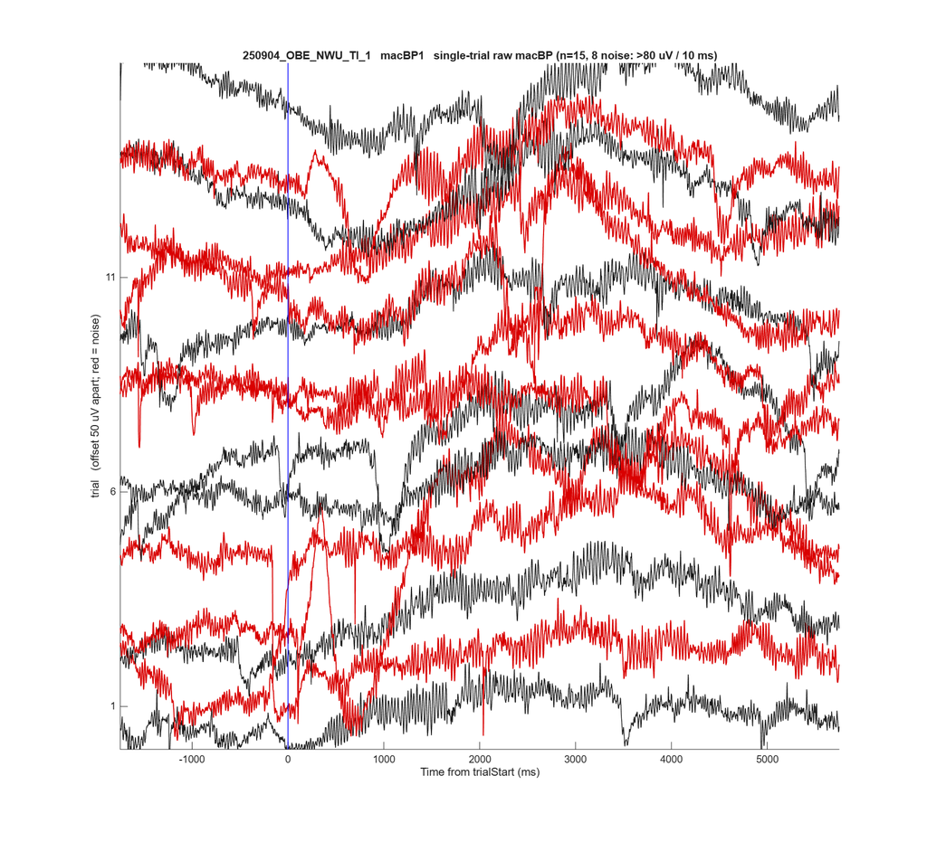

*251208_OBE_NWU_SP_1 (Control) — 25 noise sniffs*

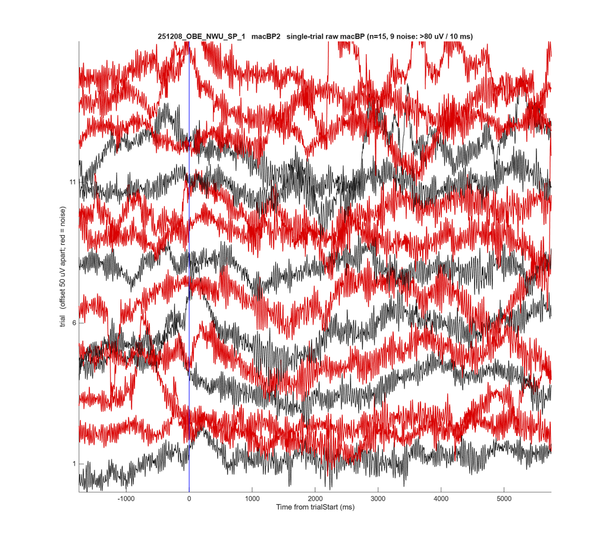

**Lowest-noise sessions:**

*250929_Dupi_NMH_GH_2 (DupiS2) — 0 noise sniffs*

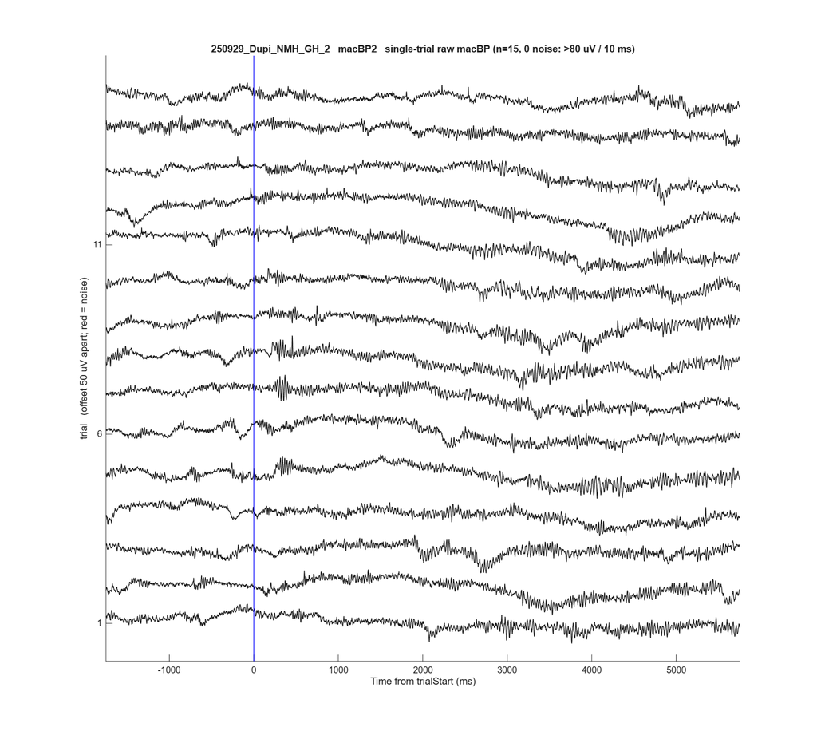

*251002_Dupi_NMH_AB_2 (DupiS2) — 0 noise sniffs*

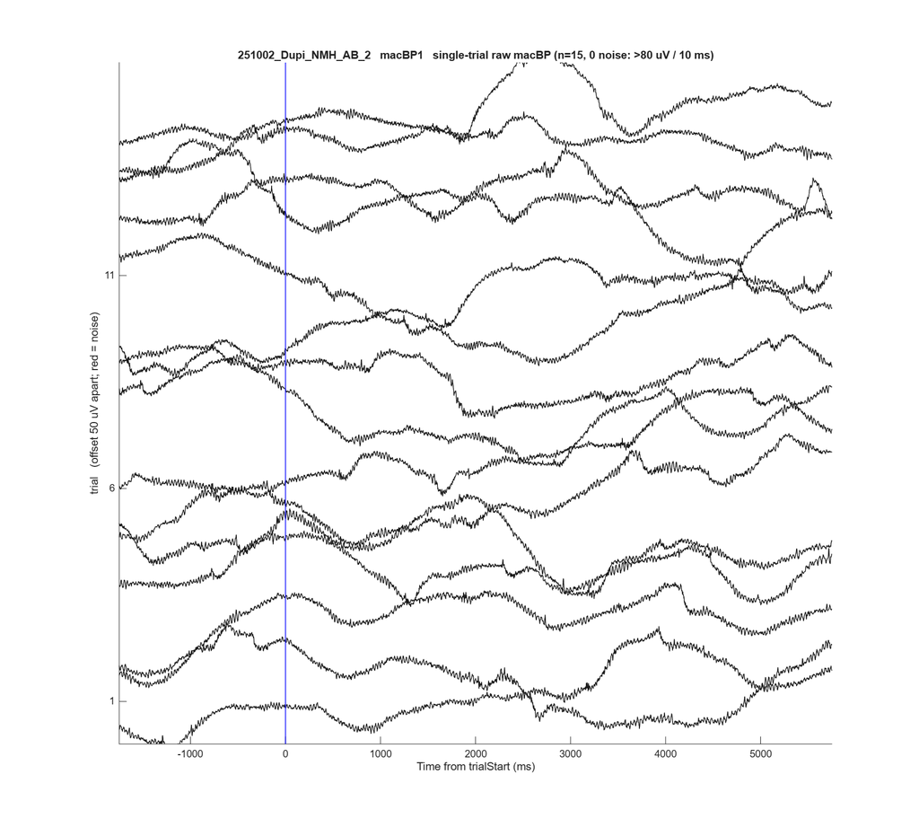

## 4. Single-subject example spectrograms

For each group, up to two example sessions, all three sniff lockings (start, free, confirm).

### DupiS1

**250623_Dupi_NMH_KS_1** (bestMac = macBP2)

*start-sniff:*

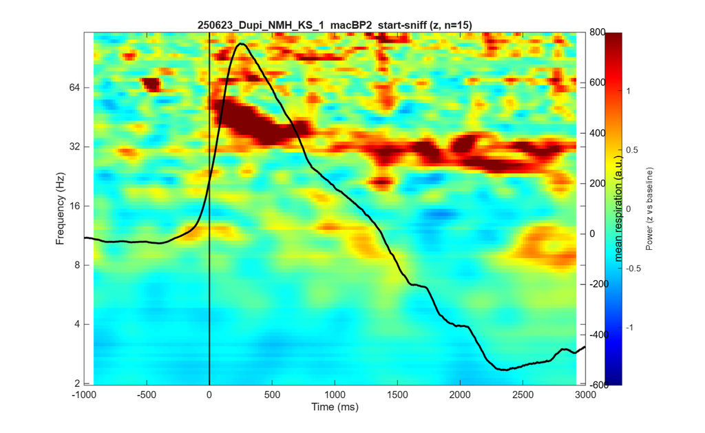

*free-sniff:*

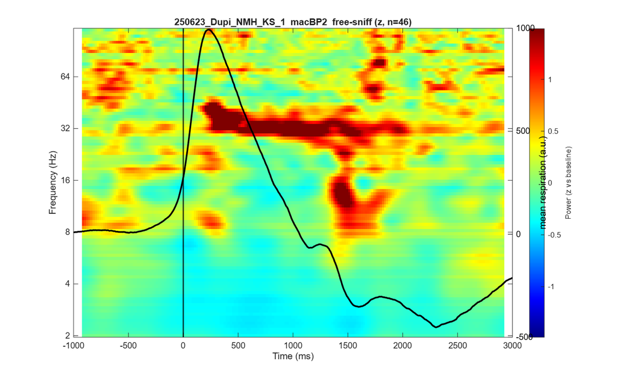

*confirm-sniff:*

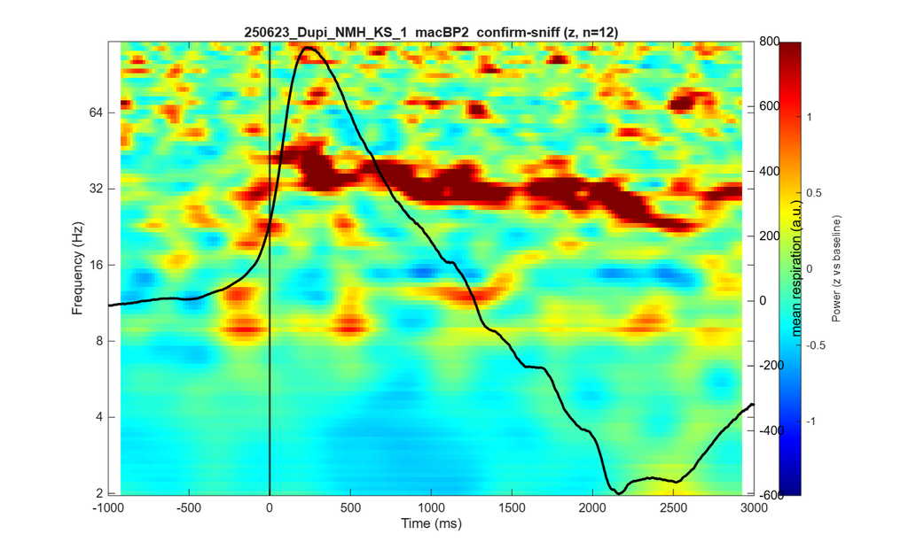

**250818_Dupi_NMH_JH_1** (bestMac = macBP2)

*start-sniff:*

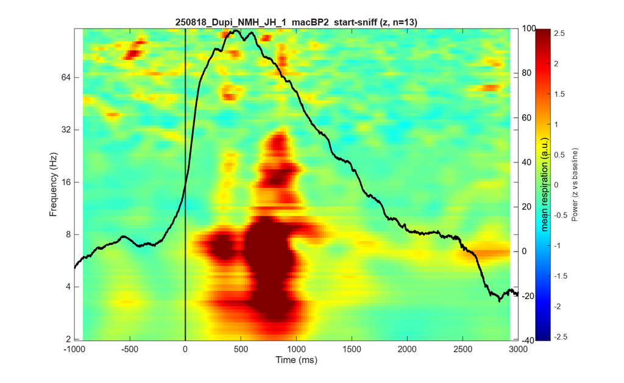

*free-sniff:*

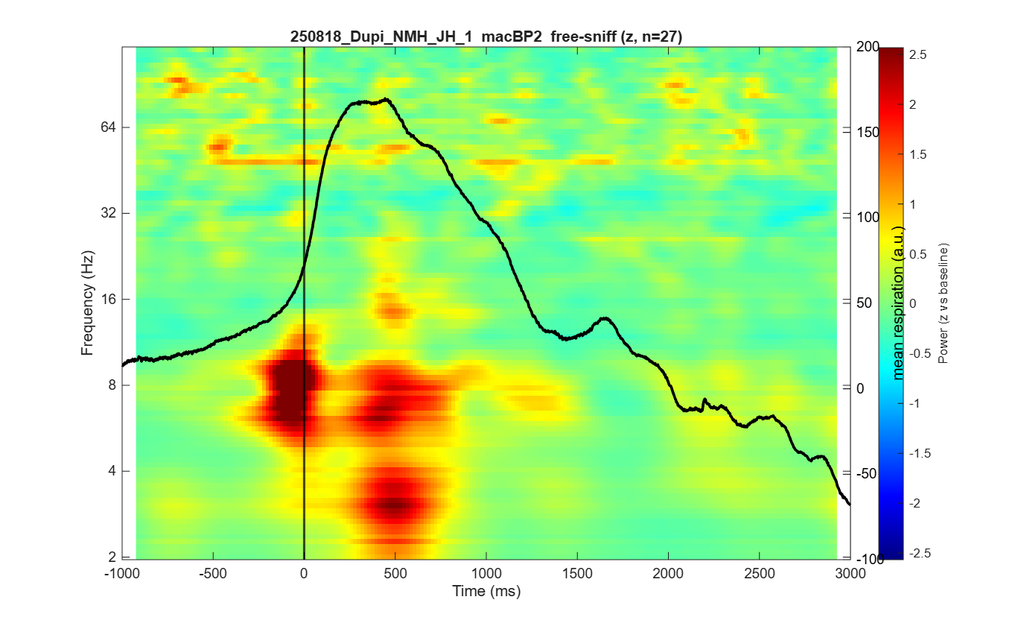

*confirm-sniff:*

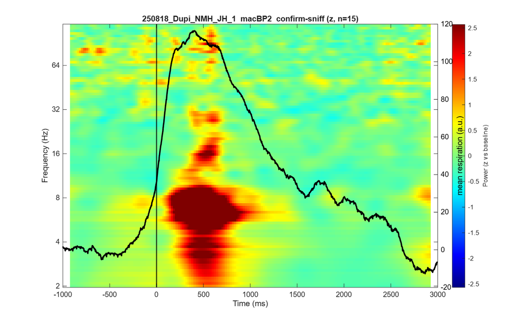

### DupiS2

**250623_Dupi_NMH_KS_2** (bestMac = macBP1)

*start-sniff:*

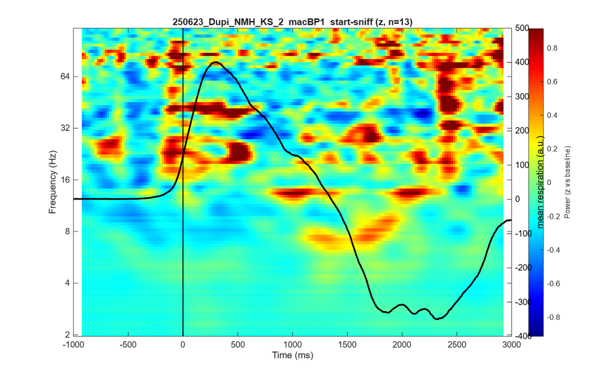

*free-sniff:*

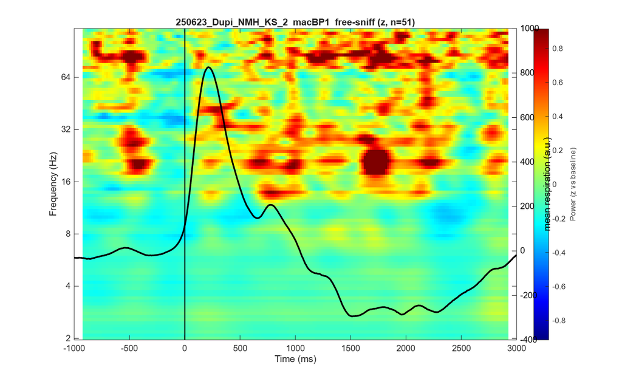

*confirm-sniff:*

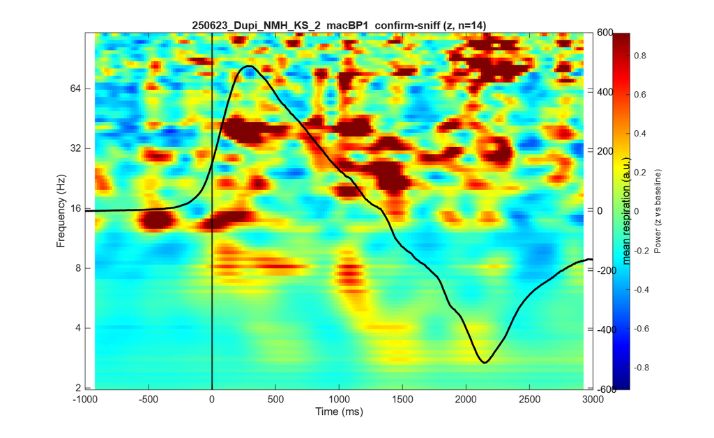

**250818_Dupi_NMH_JH_2** (bestMac = macBP2)

*start-sniff:*

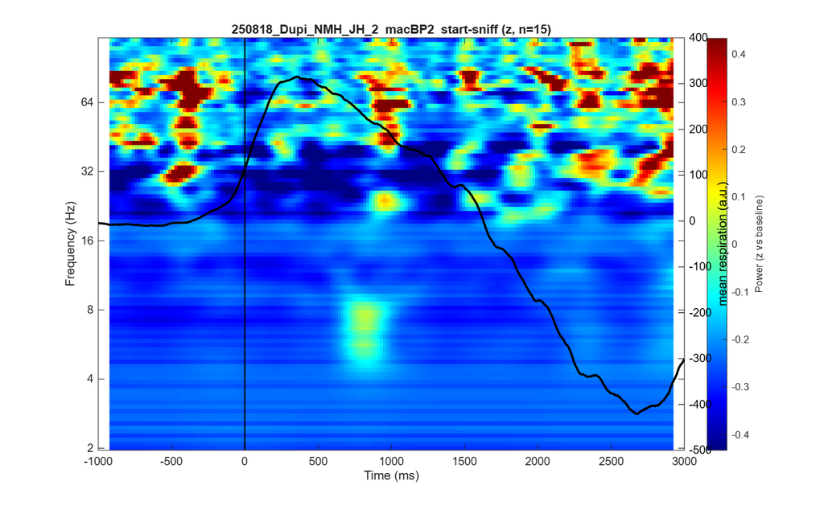

*free-sniff:*

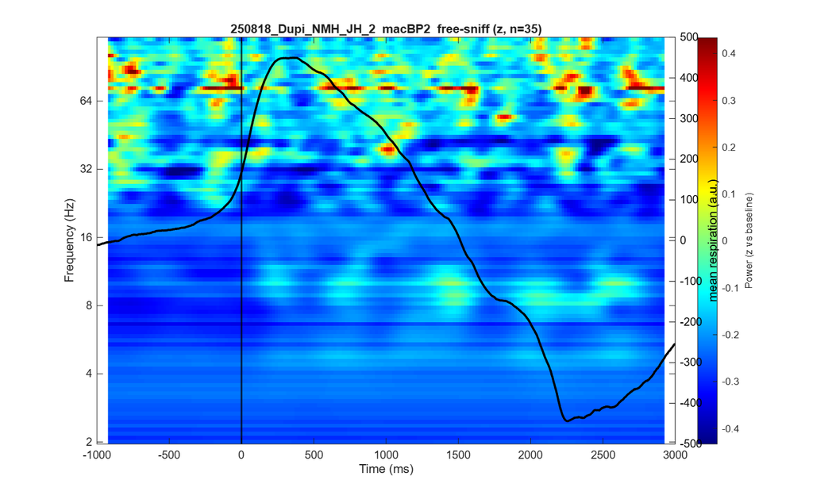

*confirm-sniff:*

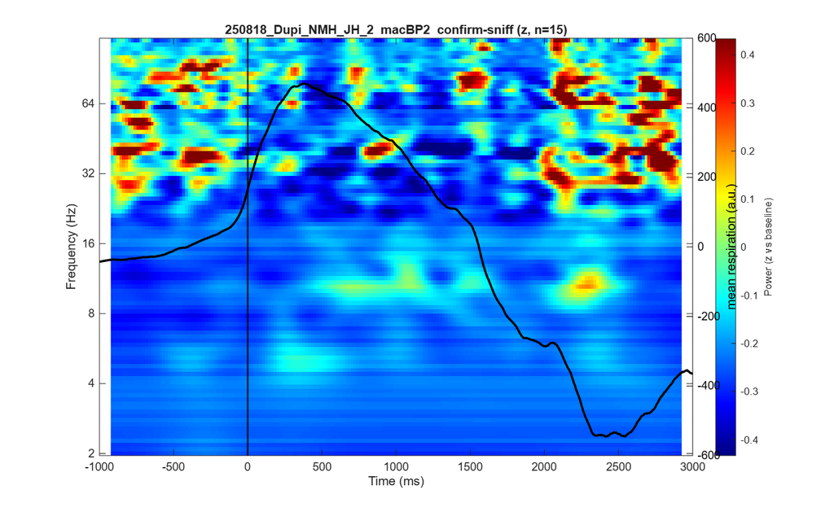

### DupiS3

*no sessions*

### Control

**250225_OBE_NWU_AS_4** (bestMac = macBP5)

*start-sniff:*

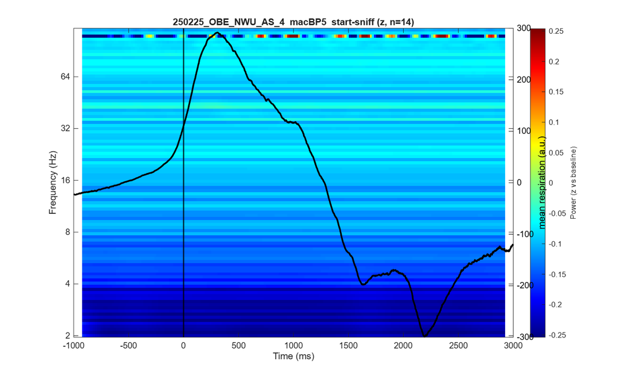

*free-sniff:*

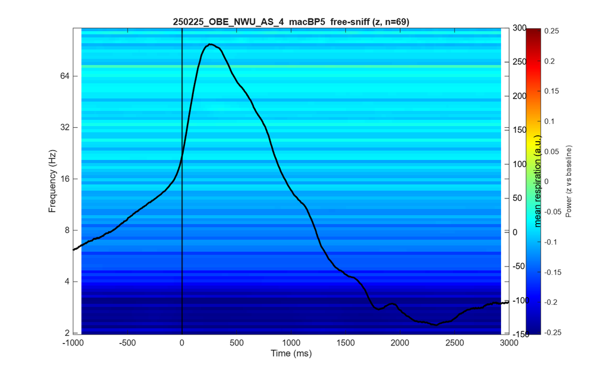

*confirm-sniff:*

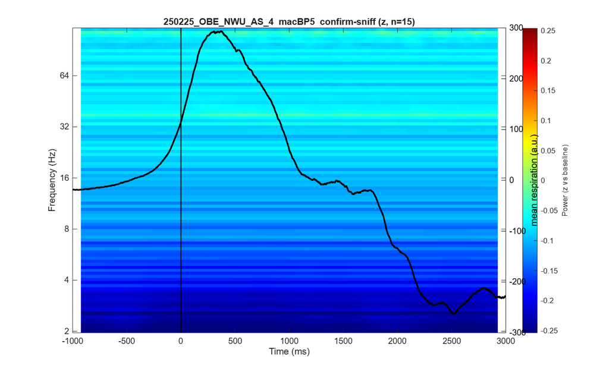

**250908_OBE_NWU_AS** (bestMac = macBP3)

*start-sniff:*

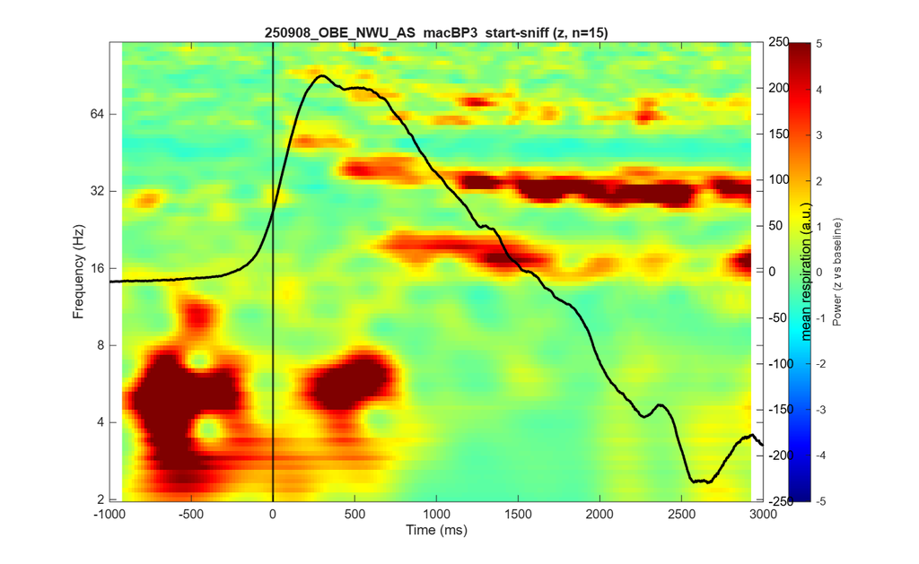

*free-sniff:*

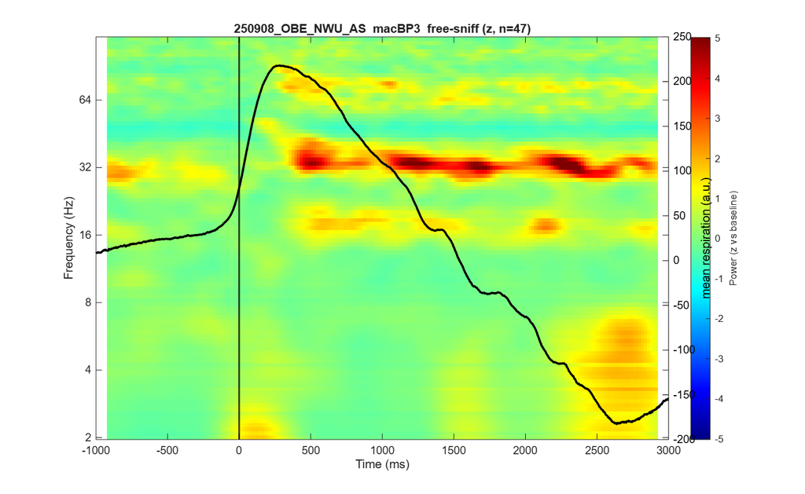

*confirm-sniff:*

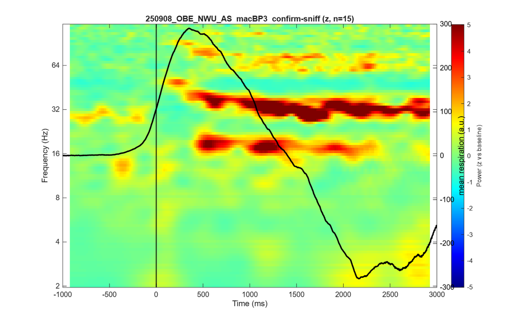

## 5. Group-average spectrograms

### DupiS1

*start-sniff:*

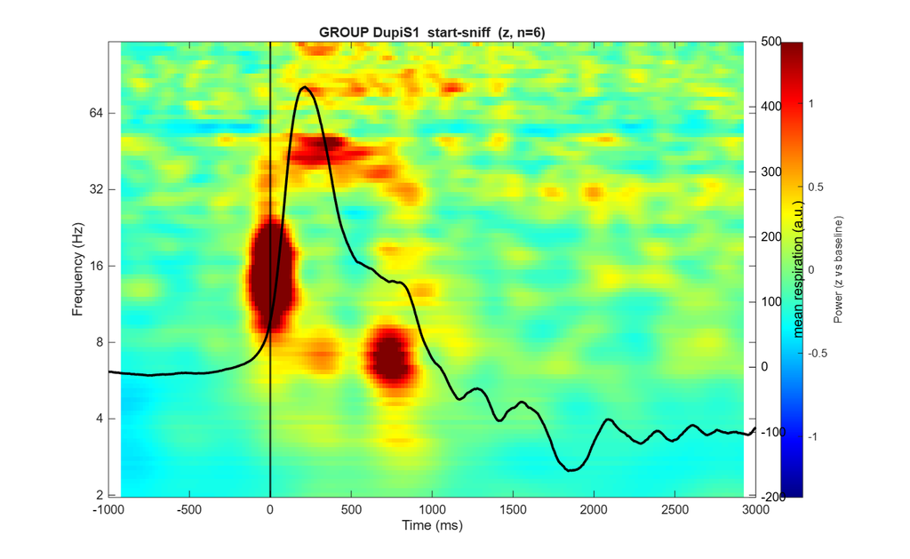

*free-sniff:*

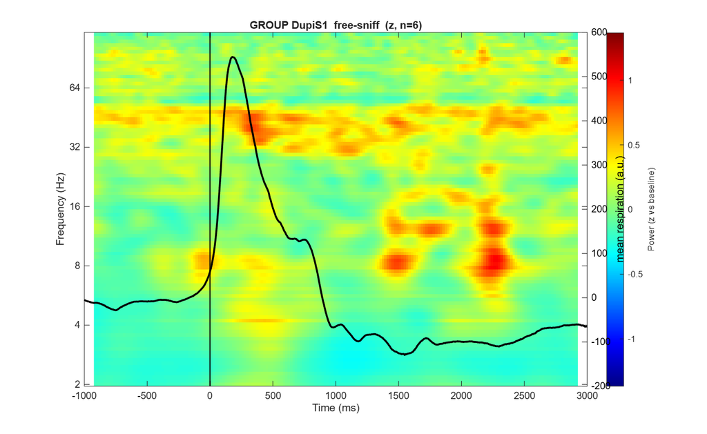

*confirm-sniff:*

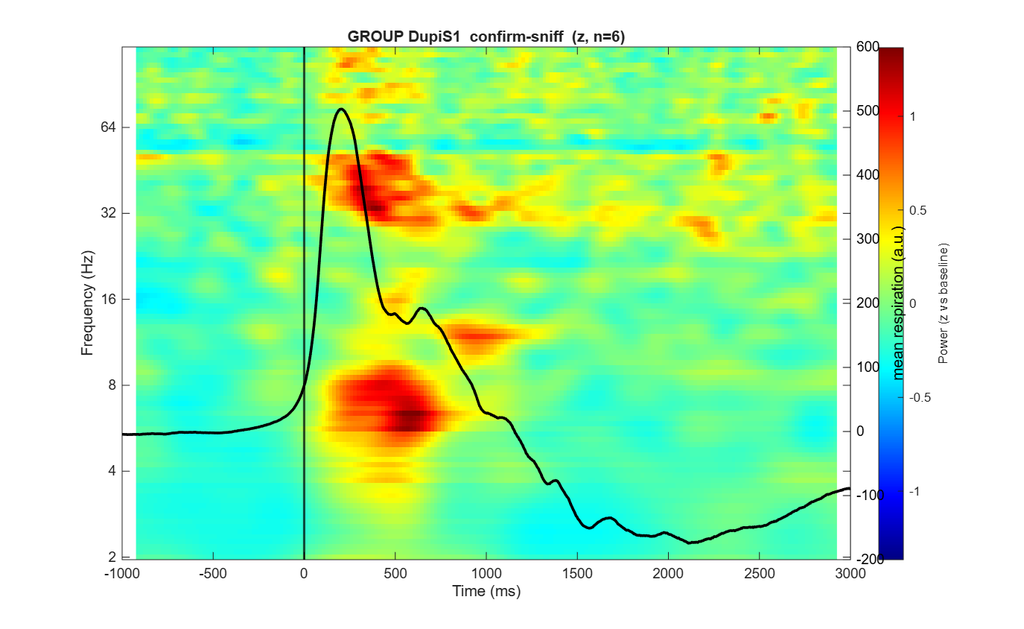

### DupiS2

*start-sniff:*

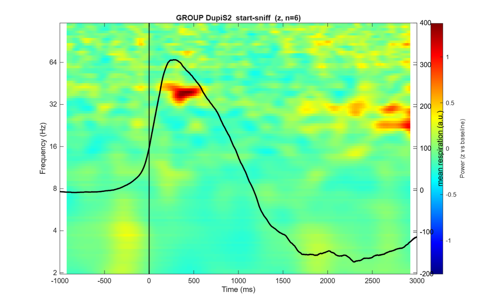

*free-sniff:*

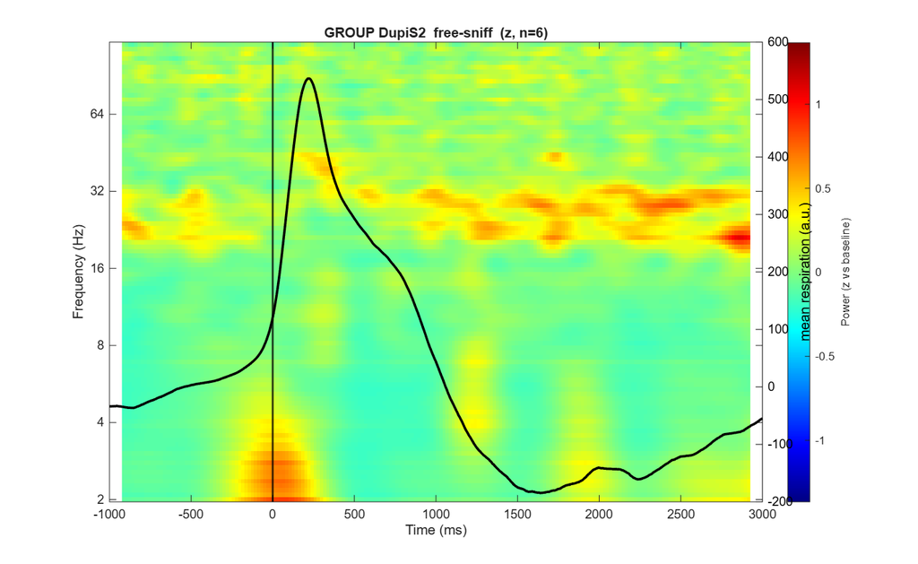

*confirm-sniff:*

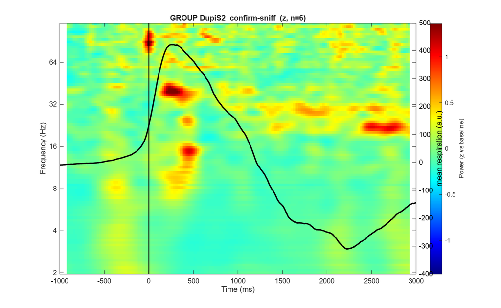

### DupiS3

*start-sniff:*

*free-sniff:*

*confirm-sniff:*

### Control

*start-sniff:*

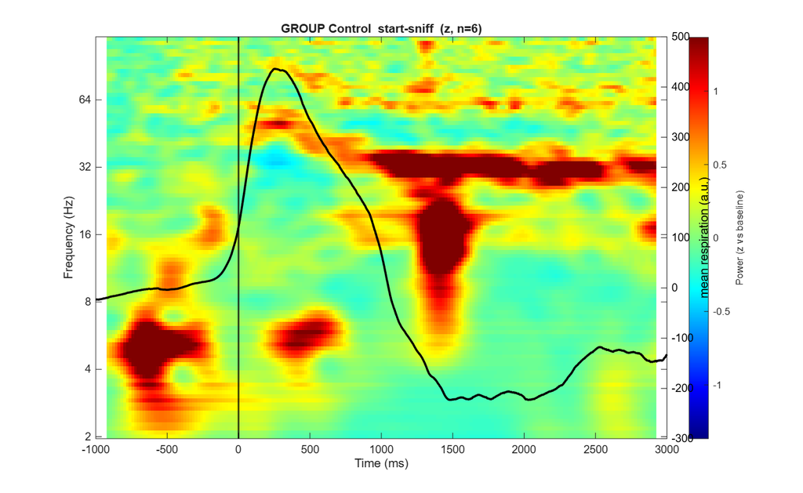

*free-sniff:*

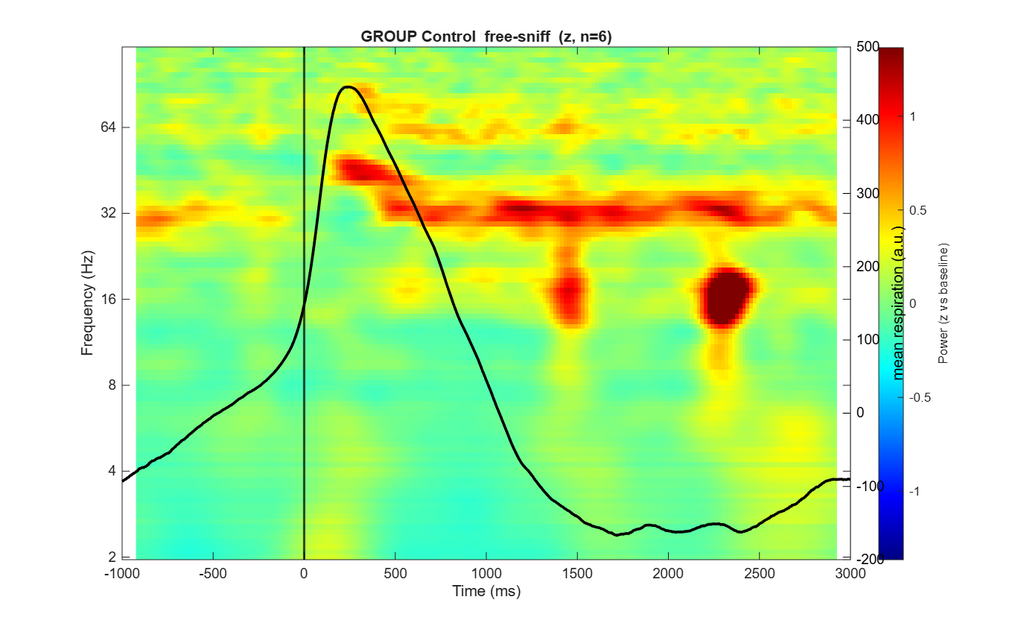

*confirm-sniff:*

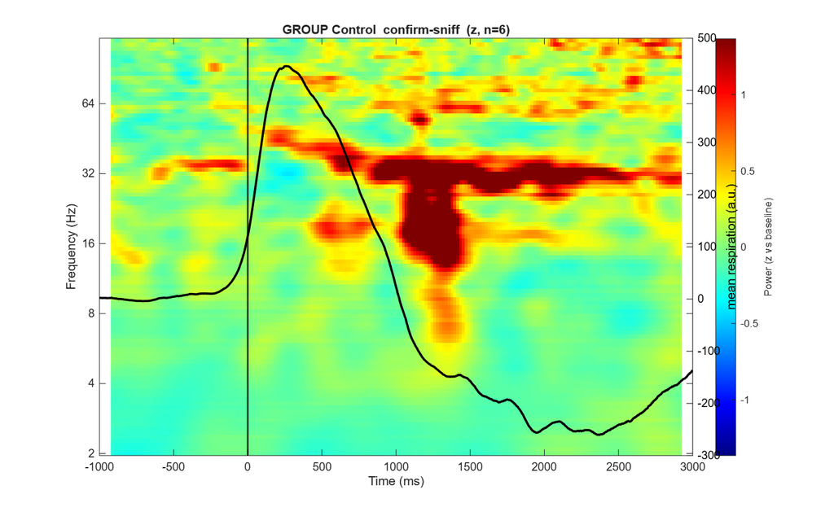